# NumPy Broadcasting & JAX

Lecture 07

Dr. Colin Rundel

# Basic file IO

## Reading and writing ndarrays

We will not spend much time on this as most data you will encounter is more likely to be in a tabular format (e.g. data frame) and tools like Pandas are more appropriate.

For basic saving and loading of NumPy arrays there are the `save()` and `load()` functions which use a custom binary format.

```python
x = np.arange(1e5)
np.save("data/x.npy", x)
```

```python
new_x = np.load("data/x.npy")
np.all(x == new_x)
```

```
np.True_
```

Additional functions for saving (`savez()`, `savez_compressed()`, `savetxt()`) exist for saving multiple arrays or saving a text representation of an array.

## Reading delimited data

While not particularly recommended, if you need to read delimited (csv, tsv, etc.) data into a NumPy array you can use `genfromtxt()`,

```python
with open("data/mtcars.csv") as file:
    mtcars = np.genfromtxt(file, delimiter=",", skip_header=True)

mtcars
```

```
array([[  6.   , 160.   , 110.   ,   3.9  ,   2.62 ,  16.46 ,   0.   ,   1.   ,   4.   ,   4.   ],
       [  6.   , 160.   , 110.   ,   3.9  ,   2.875,  17.02 ,   0.   ,   1.   ,   4.   ,   4.   ],
       [  4.   , 108.   ,  93.   ,   3.85 ,   2.32 ,  18.61 ,   1.   ,   1.   ,   4.   ,   1.   ],
       [  6.   , 258.   , 110.   ,   3.08 ,   3.215,  19.44 ,   1.   ,   0.   ,   3.   ,   1.   ],
       [  8.   , 360.   , 175.   ,   3.15 ,   3.44 ,  17.02 ,   0.   ,   0.   ,   3.   ,   2.   ],
       [  6.   , 225.   , 105.   ,   2.76 ,   3.46 ,  20.22 ,   1.   ,   0.   ,   3.   ,   1.   ],
       [  8.   , 360.   , 245.   ,   3.21 ,   3.57 ,  15.84 ,   0.   ,   0.   ,   3.   ,   4.   ],
       [  4.   , 146.7  ,  62.   ,   3.69 ,   3.19 ,  20.   ,   1.   ,   0.   ,   4.   ,   2.   ],
       [  4.   , 140.8  ,  95.   ,   3.92 ,   3.15 ,  22.9  ,   1.   ,   0.   ,   4.   ,   2.   ],
       [  6.   , 167.6  , 123.   ,   3.92 ,   3.44 ,  18.3  ,   1.   ,   0.   ,   4.   ,   4.   ],
       [  6.   , 167.6  , 123.   ,   3.92 ,   3.44 ,  18.9  ,   1.   ,   0.   ,   4.   ,   4.   ],
       [  8.   , 275.8  , 180.   ,   3.07 ,   4.07 ,  17.4  ,   0.   ,   0.   ,   3.   ,   3.   ],
       [  8.   , 275.8  , 180.   ,   3.07 ,   3.73 ,  17.6  ,   0.   ,   0.   ,   3.   ,   3.   ],
       [  8.   , 275.8  , 180.   ,   3.07 ,   3.78 ,  18.   ,   0.   ,   0.   ,   3.   ,   3.   ],
       [  8.   , 472.   , 205.   ,   2.93 ,   5.25 ,  17.98 ,   0.   ,   0.   ,   3.   ,   4.   ],
       [  8.   , 460.   , 215.   ,   3.   ,   5.424,  17.82 ,   0.   ,   0.   ,   3.   ,   4.   ],
       [  8.   , 440.   , 230.   ,   3.23 ,   5.345,  17.42 ,   0.   ,   0.   ,   3.   ,   4.   ],
       [  4.   ,  78.7  ,  66.   ,   4.08 ,   2.2  ,  19.47 ,   1.   ,   1.   ,   4.   ,   1.   ],
       [  4.   ,  75.7  ,  52.   ,   4.93 ,   1.615,  18.52 ,   1.   ,   1.   ,   4.   ,   2.   ],
       [  4.   ,  71.1  ,  65.   ,   4.22 ,   1.835,  19.9  ,   1.   ,   1.   ,   4.   ,   1.   ],
       [  4.   , 120.1  ,  97.   ,   3.7  ,   2.465,  20.01 ,   1.   ,   0.   ,   3.   ,   1.   ],
       [  8.   , 318.   , 150.   ,   2.76 ,   3.52 ,  16.87 ,   0.   ,   0.   ,   3.   ,   2.   ],
       [  8.   , 304.   , 150.   ,   3.15 ,   3.435,  17.3  ,   0.   ,   0.   ,   3.   ,   2.   ],
       [  8.   , 350.   , 245.   ,   3.73 ,   3.84 ,  15.41 ,   0.   ,   0.   ,   3.   ,   4.   ],
       [  8.   , 400.   , 175.   ,   3.08 ,   3.845,  17.05 ,   0.   ,   0.   ,   3.   ,   2.   ],
       [  4.   ,  79.   ,  66.   ,   4.08 ,   1.935,  18.9  ,   1.   ,   1.   ,   4.   ,   1.   ],
       [  4.   , 120.3  ,  91.   ,   4.43 ,   2.14 ,  16.7  ,   0.   ,   1.   ,   5.   ,   2.   ],
       [  4.   ,  95.1  , 113.   ,   3.77 ,   1.513,  16.9  ,   1.   ,   1.   ,   5.   ,   2.   ],
       [  8.   , 351.   , 264.   ,   4.22 ,   3.17 ,  14.5  ,   0.   ,   1.   ,   5.   ,   4.   ],
       [  6.   , 145.   , 175.   ,   3.62 ,   2.77 ,  15.5  ,   0.   ,   1.   ,   5.   ,   6.   ],
       [  8.   , 301.   , 335.   ,   3.54 ,   3.57 ,  14.6  ,   0.   ,   1.   ,   5.   ,   8.   ],
       [  4.   , 121.   , 109.   ,   4.11 ,   2.78 ,  18.6  ,   1.   ,   1.   ,   4.   ,   2.   ]])
```

# Broadcasting

## Broadcasting

This is an approach for deciding how to generalize operations between arrays with differing shapes.

```python
x = np.array([1, 2, 3])
```

```python
x * 2
```

```
array([2, 4, 6])
```

```python
x * np.array([2,2,2])
```

```
array([2, 4, 6])
```

```python
x * np.array([2])
```

```
array([2, 4, 6])
```

```python
x * np.array([2,2])
```

```
ValueError: operands could not be broadcast together with shapes (3,) (2,)
```

## Simplicity & Efficiency

Broadcast code is usually shorter / simpler and it can make the calculation more efficient,

```python
x = np.arange(1e5)
y = np.array([2]).repeat(1e5)
```

```python
%timeit -n 1000 x * 2
```

```
11.2 μs ± 302 ns per loop (mean ± std. dev. of 7 runs, 1,000 loops each)
```

```python
%timeit -n 1000 x * np.array([2])
```

```
11.4 μs ± 197 ns per loop (mean ± std. dev. of 7 runs, 1,000 loops each)
```

```python
%timeit -n 1000 x * y
```

```
45.7 μs ± 838 ns per loop (mean ± std. dev. of 7 runs, 1,000 loops each)
```

```python
%timeit -n 1000 x * np.array([2]).repeat(1e5)
```

```
72.7 μs ± 830 ns per loop (mean ± std. dev. of 7 runs, 1,000 loops each)
```

## Rules for Broadcasting

> When operating on two arrays, NumPy compares their shapes element-wise. It starts with the trailing (i.e. rightmost) dimensions and works its way left. Two dimensions are compatible when
> 1. they are equal, or
> 2. one of them is 1

> If these conditions are not met, a `ValueError: operands could not be broadcast together` exception is thrown, indicating that the arrays have incompatible shapes. The size of the resulting array is the size that is not 1 along each axis of the inputs.

## Example

Why does the code on the left work but not the code on the right?

```python
x = np.arange(12).reshape((4,3)); x

x + np.array([1,2,3])
```

```
array([[ 1,  3,  5],
       [ 4,  6,  8],
       [ 7,  9, 11],
       [10, 12, 14]])
```

```python
x = np.arange(12).reshape((3,4)); x

x + np.array([1,2,3])
```

```
ValueError: operands could not be broadcast together with shapes (3,4) (3,)
```

```
    x    (2d array): 4 x 3
    y    (1d array):     3
    ----------------------
    x+y  (2d array): 4 x 3
```

```
    x    (2d array): 3 x 4
    y    (1d array):     3
    ----------------------
    x+y  (2d array): Error
```

## A fix

```python
x = np.arange(12).reshape((3,4)); x
```

```
array([[ 0,  1,  2,  3],
       [ 4,  5,  6,  7],
       [ 8,  9, 10, 11]])
```

```python
x + np.array([1,2,3]).reshape(3,1)
```

```
array([[ 1,  2,  3,  4],
       [ 6,  7,  8,  9],
       [11, 12, 13, 14]])
```

```
    x    (2d array): 3 x 4
    y    (2d array): 3 x 1
    ----------------------
    x+y  (2d array): 3 x 4
```

## Examples (2)

```python
x = np.array([0,10,20,30]).reshape((4,1))
y = np.array([1,2,3])
```

```python
x
```

```
array([[ 0],
       [10],
       [20],
       [30]])
```

```python
y
```

```
array([1, 2, 3])
```

```python
x+y
```

```
array([[ 1,  2,  3],
       [11, 12, 13],
       [21, 22, 23],
       [31, 32, 33]])
```

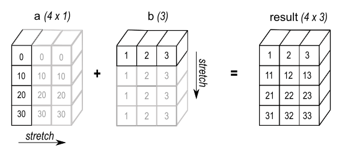

From NumPy user guide - [Broadcasting](https://numpy.org/doc/stable/user/basics.broadcasting.html)

## Unintended broadcasting

A common Broadcasting pitfalls is accidental broadcasting where operations succeed but produce unexpected results,

```python
data = np.array([[1, 2, 3],
                 [4, 5, 6],
                 [7, 8, 9]])
row_means = data.mean(axis=1)  # mean of each row: [2, 5, 8]
```

Now we’d like to substract each row’s mean from that row.

```python
data - row_means
```

```
array([[-1., -3., -5.],
       [ 2.,  0., -2.],
       [ 5.,  3.,  1.]])
```

This “worked” but gave the wrong answer. The `(3,)` array broadcast across columns, not rows.

```python
data - row_means.reshape(3, 1)
```

```
array([[-1.,  0.,  1.],
       [-1.,  0.,  1.],
       [-1.,  0.,  1.]])
```

## 1d, row, and column vectors

Easy to get confused between `(n,)`, `(n,1)`, and `(1,n)` shapes’ behavior,

```python
v = np.array([1, 2, 3])
v.shape
```

```
(3,)
```

```python
v_col = v.reshape(3, 1)
v_col.shape
```

```
(3, 1)
```

```python
v_row = v.reshape(1, 3)
v_row.shape
```

```
(1, 3)
```

```python
m = np.ones((3, 3))
```

```python
m + v
```

```
array([[2., 3., 4.],
       [2., 3., 4.],
       [2., 3., 4.]])
```

```python
m + v_col
```

```
array([[2., 2., 2.],
       [3., 3., 3.],
       [4., 4., 4.]])
```

```python
m + v_row
```

```
array([[2., 3., 4.],
       [2., 3., 4.],
       [2., 3., 4.]])
```

All three succeed but `v` and `v_row` broadcast across rows while `v_col` broadcasts across columns.

## Size explosion

Broadcasting doesn’t copy data during the operation, but the *result* can be much larger than expected.

```python
a = np.zeros((1000, 1))     # ~8 KB
b = np.zeros((1, 1000))     # ~8 KB
c = a + b                   # ~8 MB
c.shape
```

```
(1000, 1000)
```

You can use `np.broadcast_shapes()` to quick check the result shape before operating:

```python
np.broadcast_shapes(a.shape, b.shape)
```

```
(1000, 1000)
```

```python
np.broadcast_shapes((10000, 1), (1, 10000))
```

```
(10000, 10000)
```

## Broadcasting with matrix multiplication

The `@` operator (and `np.matmul()`) has special broadcasting rules:

- The last two dimensions are treated as matrices and must be compatible for matrix multiplication (inner dimensions must match)
- Broadcasting applies only to the “batch” dimensions (all dimensions except the last two)

```python
A = np.ones((3, 2, 4))
B = np.ones((4, 5))
(A @ B).shape
```

```
(3, 2, 5)
```

```python
A = np.ones((3, 2, 4))
B = np.ones((3, 4, 5))
(A @ B).shape
```

```
(3, 2, 5)
```

```python
A = np.ones((2, 1, 2, 4))
B = np.ones((3, 4, 5))
(A @ B).shape
```

```
(2, 3, 2, 5)
```

```python
A = np.ones((2, 2, 4))
B = np.ones((3, 4, 5))
A @ B
```

```
ValueError: operands could not be broadcast together with remapped shapes [original->remapped]: (2,2,4)->(2,newaxis,newaxis) (3,4,5)->(3,newaxis,newaxis)  and requested shape (2,5)
```

## Exercise 1

For each of the following combinations determine what the resulting dimension will be using broadcasting

- A [128 x 128 x 3] + B [3]
- A [8 x 1 x 6 x 1] + B [7 x 1 x 5]
- A [2 x 1] + B [8 x 4 x 3]
- A [3 x 1] + B [15 x 3 x 5]
- A [3] + B [4]

## Demo 1 - Standardization

Below we generate a data set with 3 columns of random normal values. Each column has a different mean and standard deviation which we can check with `mean()` and `std()`.

```python
rng = np.random.default_rng(1234)
d = rng.normal(
  loc=[-1,0,1],
  scale=[1,2,3],
  size=(1000,3)
)
```

```python
d.shape
```

```
(1000, 3)
```

```python
d.mean(axis=0)
```

```
array([-1.02944, -0.01396,  1.01242])
```

```python
d.std(axis=0)
```

```
array([0.99675, 2.03223, 3.10625])
```

Let’s use broadcasting to standardize all three columns to have mean 0 and standard deviation 1.

## Broadcasting and assignment

In addition to arithmetic operators, broadcasting can be used with assignment via array indexing,

```python
x = np.arange(12).reshape((3,4))
y = -np.arange(4)
z = -np.arange(3)
```

```python
x[:] = y
x
```

```
array([[ 0, -1, -2, -3],
       [ 0, -1, -2, -3],
       [ 0, -1, -2, -3]])
```

```python
x[...] = y
x
```

```
array([[ 0, -1, -2, -3],
       [ 0, -1, -2, -3],
       [ 0, -1, -2, -3]])
```

```python
x[:] = z
```

```
ValueError: could not broadcast input array from shape (3,) into shape (3,4)
```

```python
x[:] = z.reshape((3,1))
x
```

```
array([[ 0,  0,  0,  0],
       [-1, -1, -1, -1],
       [-2, -2, -2, -2]])
```

# JAX

## JAX

> JAX is a library for array-oriented numerical computation (à la NumPy), with automatic differentiation and JIT compilation to enable high-performance machine learning research.
> - JAX provides a unified NumPy-like interface to computations that run on CPU, GPU, or TPU, in local or distributed settings.
> - JAX features built-in Just-In-Time (JIT) compilation via Open XLA, an open-source machine learning compiler ecosystem.
> - JAX functions support efficient evaluation of gradients via its automatic differentiation transformations.
> - JAX functions can be automatically vectorized to efficiently map them over arrays representing batches of inputs.

```python
import jax
jax.__version__
```

```
'0.9.0'
```

## A Brief History

JAX is just one framework in a long history going back almost 20 years. These frameworks all share a common approach: representing computations as a graph of operations.

This enables automatic differentiation (via backpropagation) and optimization/compilation for efficient execution on GPUs or other specialized hardware.

- Theano (2007) - U of Montreal
- TensorFlow (2015) - Google Brain
- PyTorch (2016) - Facebook
- JAX (2018) - Google

## JAX & NumPy

```python
import numpy as np

x_np = np.arange(6).reshape(2, 3)
x_np
```

```
array([[0, 1, 2],
       [3, 4, 5]])
```

```python
np.sum(x_np ** 2)
```

```
np.int64(55)
```

```python
type(x_np)
```

```
numpy.ndarray
```

```python
import jax.numpy as jnp

x_jnp = jnp.arange(6).reshape(2, 3)
x_jnp
```

```
Array([[0, 1, 2],
       [3, 4, 5]], dtype=int32)
```

```python
jnp.sum(x_jnp ** 2)
```

```
Array(55, dtype=int32)
```

```python
type(x_jnp)
```

```
jaxlib._jax.ArrayImpl
```

## Compatibility

```python
y_mix = 2 * np.sin(x_jnp) * jnp.cos(x_np); y_mix
```

```
Array([[ 0.     ,  0.9093 , -0.7568 ],
       [-0.27942,  0.98936, -0.54402]], dtype=float32)
```

```python
type(y_mix)
```

```
jaxlib._jax.ArrayImpl
```

```python
y_mix = 2 * jnp.sin(x_np) * jnp.cos(x_np); y_mix
```

```
Array([[ 0.     ,  0.9093 , -0.7568 ],
       [-0.27942,  0.98936, -0.54402]], dtype=float32)
```

```python
type(y_mix)
```

```
jaxlib._jax.ArrayImpl
```

```python
y_mix = 2 * np.sin(x_jnp) * np.cos(x_jnp); y_mix
```

```
array([[ 0.     ,  0.9093 , -0.7568 ],
       [-0.27942,  0.98936, -0.54402]])
```

```python
type(y_mix)
```

```
numpy.ndarray
```

## JAX Arrays

As we’ve just seen a JAX array is very similar to a NumPy array but there are some important differences.

- JAX arrays are immutable*

```python
x = jnp.array([3, 2, 1])
x[0] = 2
```

```
TypeError: JAX arrays are immutable and do not support in-place item assignment. Instead of x[idx] = y, use x = x.at[idx].set(y) or another .at[] method: https://docs.jax.dev/en/latest/_autosummary/jax.numpy.ndarray.at.html
```

- Related to the above, JAX does not support in-place operations - these functions now create and return a copy of the array

```python
y = x.sort()
```

```python
y
```

```
Array([1, 2, 3], dtype=int32)
```

```python
x
```

```
Array([3, 2, 1], dtype=int32)
```

```python
np.shares_memory(x,y)
```

```
False
```

- The default JAX array dtypes are 32 bits not 64 bits (i.e. `float32` not `float64` and `int32` not `int64`)

  ```python
  jnp.array([1, 2, 3])
  ```

  ```
  Array([1, 2, 3], dtype=int32)
  ```

  ```python
  jnp.array([1., 2., 3.])
  ```

  ```
  Array([1., 2., 3.], dtype=float32)
  ```

  ```python
  #| warning: true
  jnp.array([1, 2, 3], dtype=jnp.float64)
  ```

  ```
  UserWarning: Explicitly requested dtype float64 requested in array is not available, and
  will be truncated to dtype float32. To enable more dtypes, set the jax_enable_x64 configuration
  option or the JAX_ENABLE_X64 shell environment variable. See
  https://github.com/jax-ml/jax#current-gotchas for more.
  jnp.array([1, 2, 3], dtype=jnp.float64)

  Array([1., 2., 3.], dtype=float32)
  ```

  64-bit dtypes can be enabled by setting `jax_enable_x64=True` in the JAX configuration.

  ```python
  jax.config.update("jax_enable_x64", True)
  ```

  ```python
  jnp.array([1, 2, 3])
  ```

  ```
  Array([1, 2, 3], dtype=int64)
  ```

  ```python
  jnp.array([1., 2., 3.])
  ```

  ```
  Array([1., 2., 3.], dtype=float64)
  ```

- JAX arrays are allocated to one *or more* devices

  ```python
  jax.devices()
  ```

  ```
  [CpuDevice(id=0)]
  ```

  ```python
  x.devices()
  ```

  ```
  {CpuDevice(id=0)}
  ```

  ```python
  x.sharding
  ```

  ```
  SingleDeviceSharding(device=CpuDevice(id=0), memory_kind=device)
  ```

- Using JAX interactively allows for the use of standard Python control flow (`if`, `while`, `for`, etc.) but this is not supported for some of JAX’s more advanced operations (e.g. `jit` and `grad`)

  There are replacements for most of these constructs in JAX, but they are beyond the scope of this lecture.

# Random number generation

## JAX vs NumPy

Pseudo random number generation in JAX is a bit different than with NumPy - the latter depends on a global state that is updated each time a random function is called.

NumPy’s PRNG guarantees something called sequential equivalence which amounts to sampling N numbers sequentially is the same as sampling N numbers at once (e.g. a vector of length N).

```python
np.random.seed(0)
f"individually: {np.stack([np.random.uniform() for i in range(5)])}"
```

```
'individually: [0.54881 0.71519 0.60276 0.54488 0.42365]'
```

```python
np.random.seed(0)
f"at once: {np.random.uniform(size=5)}"
```

```
'at once: [0.54881 0.71519 0.60276 0.54488 0.42365]'
```

## Parallelization & sequential equivalence

Sequential equivalence can be problematic when using parallelization across multiple devices, consider the following code:

```python
np.random.seed(0)

def bar():
  return np.random.uniform()

def baz():
  return np.random.uniform()

def foo():
  return bar() + 2 * baz()
```

How do we guarantee that we get consistent results if we don’t know the order that `bar()` and `baz()` will run?

## PRNG keys

JAX makes use of *random keys* which are just a fancier version of random seeds - all of JAX’s random functions require a key as their first argument.

```python
key = jax.random.PRNGKey(1234); key
```

```
Array([   0, 1234], dtype=uint32)
```

```python
jax.random.normal(key)
```

```
Array(1.1031, dtype=float32)
```

```python
jax.random.normal(key)
```

```
Array(1.1031, dtype=float32)
```

```python
jax.random.normal(key, shape=(3,))
```

```
Array([ 1.1031 ,  0.86306, -0.33868], dtype=float32)
```

Note that JAX does not provide a sequential equivalence guarantee - this is so that it can support vectorization for the generation of pseudo-random numbers.

## Splitting keys

Since a key is essentially a seed we do not want to reuse them (unless we want an identical output). Therefore to generate multiple different PRN we can split a key to deterministically generate two (or more) new keys.

```python
key11, key12 = jax.random.split(key)
f"{key=}"
f"{key11=}"
f"{key12=}"
```

```
'key12=Array([2877103387, 1697627890], dtype=uint32)'
```

```python
key21, key22 = jax.random.split(key)
f"{key=}"
f"{key21=}"
f"{key22=}"
```

```
'key22=Array([2877103387, 1697627890], dtype=uint32)'
```

```python
key3 = jax.random.split(key, num=3)
key3
```

```
Array([[1264997412, 2518116175],
       [2877103387, 1697627890],
       [2113592192,  603280156]], dtype=uint32)
```

```python
jax.random.normal(key, shape=(3,))
```

```
Array([ 1.1031 ,  0.86306, -0.33868], dtype=float32)
```

```python
jax.random.normal(key11, shape=(3,))
jax.random.normal(key12, shape=(3,))
```

```
Array([ 1.49837, -1.47306, -2.08758], dtype=float32)
```

```python
jax.random.normal(key21, shape=(3,))
jax.random.normal(key22, shape=(3,))
```

```
Array([ 1.49837, -1.47306, -2.08758], dtype=float32)
```

```python
jax.random.normal(key3[0], shape=(3,))
jax.random.normal(key3[1], shape=(3,))
jax.random.normal(key3[2], shape=(3,))
```

```
Array([ 0.32401,  1.3939 , -1.17673], dtype=float32)
```

# JAX & jit

## Just-in-time compilation

JAX’s `jit()` function compiles a function using XLA (Accelerated Linear Algebra), which can significantly speed up execution by optimizing the computation graph and reducing Python overhead.

```python
def SELU_np(x, α=1.67, λ=1.05):
  "Scaled Exponential Linear Unit"
  return λ * np.where(x > 0, x, α * np.exp(x) - α)

x = np.linspace(-10, 10, int(1e6))
%timeit y = SELU_np(x)
```

```
2.7 ms ± 34.4 μs per loop (mean ± std. dev. of 7 runs, 100 loops each)
```

```python
def SELU_jnp(x, α=1.67, λ=1.05):
  "Scaled Exponential Linear Unit"
  return λ * jnp.where(x > 0, x, α * jnp.exp(x) - α)

x = jnp.linspace(-10, 10, 1000000)
%timeit -r 3 y = SELU_jnp(x)
```

```
342 μs ± 721 ns per loop (mean ± std. dev. of 3 runs, 1,000 loops each)
```

```python
SELU_jnp_jit = jax.jit(SELU_jnp)
%timeit -r 3 y = SELU_jnp_jit(x)
```

```
160 μs ± 544 ns per loop (mean ± std. dev. of 3 runs, 10,000 loops each)
```

## jit() limitations

When it works the jit tool is fantastic, but it does have a number of limitations,

- Must use [pure functions](https://jax.readthedocs.io/en/latest/notebooks/Common_Gotchas_in_JAX.html#pure-functions) (no side effects)
- Must primarily use JAX functions
  - e.g. use `jnp.minimum()` not `np.minimum()` or `min()`
- Must generally avoid conditionals / control flow
- Issues around concrete values when tracing (static values)
- Check performance - there are not always gains + there is the initial cost of compilation

# Automatic differentiation

## Basics

The `grad()` function takes a numerical function, returning a scalar, and returns a function for calculating the gradient of that function.

```python
def f(x):
  return x**2
```

```python
f(3.)
```

```
9.0
```

```python
jax.grad(f)(3.)
```

```
Array(6., dtype=float32, weak_type=True)
```

```python
jax.grad(
  jax.grad(f)
)(3.)
```

```
Array(2., dtype=float32, weak_type=True)
```

```python
def g(x):
  return jnp.exp(-x)
```

```python
g(1.)
```

```
Array(0.36788, dtype=float32, weak_type=True)
```

```python
jax.grad(g)(1.)
```

```
Array(-0.36788, dtype=float32, weak_type=True)
```

```python
jax.grad(
  jax.grad(g)
)(1.)
```

```
Array(0.36788, dtype=float32, weak_type=True)
```

```python
def h(x):
  return jnp.maximum(0,x)
```

```python
h(-2.)
```

```
Array(0., dtype=float32, weak_type=True)
```

```python
h(2.)
```

```
Array(2., dtype=float32, weak_type=True)
```

```python
jax.grad(h)(-2.)
```

```
Array(0., dtype=float32, weak_type=True)
```

```python
jax.grad(h)(2.)
```

```
Array(1., dtype=float32, weak_type=True)
```

## Aside - `vmap()`

I would like to plot `h()` and `jax.grad(h)()` - lets see what happens,

```python
x = jnp.linspace(-3,3,101)
y = h(x)
y_grad = jax.grad(h)(x)
```

```
TypeError: Gradient only defined for scalar-output functions. Output had shape: (101,).
```

We can only calculate the gradient for scalar valued functions. However, we can transform our scalar function into a vectorized function using `vmap()`.

```python
h_grad = jax.vmap(
  jax.grad(h)
)
y_grad = h_grad(x); y_grad
```

```
Array([0., 0., 0., 0., 0., 0., 0., 0., 0., 0., 0., 0., 0., 0., 0., 0., 0., 0., 0., 0., 0., 0., 0.,
       0., 0., 0., 0., 0., 0., 0., 0., 0., 0., 0., 0., 0., 0., 0., 0., 0., 0., 0., 0., 0., 0., 0.,
       0., 0., 0., 0., 0., 1., 1., 1., 1., 1., 1., 1., 1., 1., 1., 1., 1., 1., 1., 1., 1., 1., 1.,
       1., 1., 1., 1., 1., 1., 1., 1., 1., 1., 1., 1., 1., 1., 1., 1., 1., 1., 1., 1., 1., 1., 1.,
       1., 1., 1., 1., 1., 1., 1., 1., 1.], dtype=float32)
```

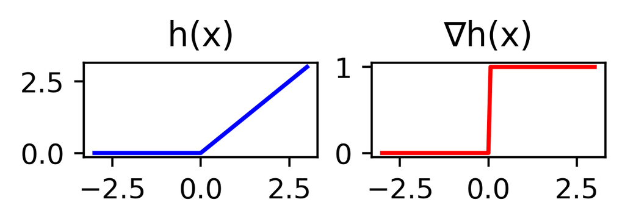

`vmap()` is significantly more powerful than just this as it allows for mapping over multiple input and output axes

## Another quick example

```python
x = jnp.linspace(-6,6,101)
f = lambda x: 0.5 * (jnp.tanh(x / 2) + 1)
y = f(x)
y_grad = jax.vmap(jax.grad(f))(x)
```

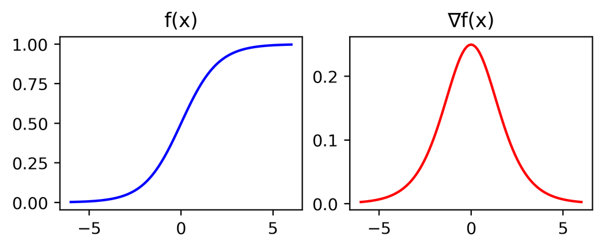

# JAX & GPUs

## Installation

JAX requires different packages depending on your hardware.

With `uv`:

```bash
# CPU only
uv add jax

# NVIDIA GPU (CUDA)
uv add jax[cuda13] # match the cuda version

# Apple Silicon (Metal)
uv add jax-metal
```

The GPU versions require appropriate drivers and libraries (CUDA toolkit for NVIDIA, Metal for Apple Silicon).

The GPU versions can be more fragile - if you run into issues `uv remove` and default to the CPU version.

## GPU Acceleration

One of JAX’s main advantages is seamless GPU support. Once installed correctly, JAX automatically uses available GPUs without requiring code changes.

```python
jax.devices()
```

```
[CpuDevice(id=0)]
```

To check which backend JAX is using:

```python
jax.default_backend()
```

```
'cpu'
```

Arrays are automatically placed on the default device, but you can explicitly control placement:

```python
# Place array on specific device
gpu = jax.devices('gpu')[0]
x_gpu = jax.device_put(x, gpu)
```

## JAX performance (GPU)

```python
key = jax.random.PRNGKey(1234)
x_jnp = jax.random.normal(key, (1000,1000))
x_np = np.array(x_jnp)
x_jnp.device
```

```
CudaDevice(id=0)
```

```python
%timeit y = x_np @ x_np
```

```
1.55 ms ± 118 μs per loop (mean ± std. dev. of 7 runs, 1,000 loops each)
```

```python
%timeit y = x_jnp @ x_jnp
```

```
99.8 μs ± 517 ns per loop (mean ± std. dev. of 7 runs, 10,000 loops each)
```

```python
%timeit y = 3*x_np + x_np
```

```
152 μs ± 612 ns per loop (mean ± std. dev. of 7 runs, 10,000 loops each)
```

```python
%timeit y = 3*x_jnp + x_jnp
```

```
59.4 μs ± 41.5 ns per loop (mean ± std. dev. of 7 runs, 10,000 loops each)
```